# Assignment2_717_oh

# Introduction

SCN2A는 신경세포에 있는 Na<sup>+</sup> channel Nav1.2를 코딩하는 유전자 이다. Nav1.2 channel은 Voltage-gated으로 early neurodevelopment 도중 action porential을 initation하는데 critical한 ㅇ역활을 한다. 최근에 연구 결과에서는 이 채널이 기능을 못하는 mutation이 일어났을 경우 autism spectrum disorders(ASD) 즉 자폐증을 유발 할 수 있으며, 반대로 기능이 과다한 mutation이 일어났을 경우 유아 발작을 일으키게 된다.

SCN2A data set은 functional consequence에 관한 annotation을 포함하고 있고, 정상인과 환자들 간으로 나누어서 mutation이 정리되어 있다. 이에 SCN2A data set을 살펴보아 visualization을 진행할 주제를 정하고, 실제 Visualization을 통해서 어떤 유의미한 결과가 있는지 살펴보려고 한다.

# Method

## 1. dataset 살피기

먼저 SCN2A dataset을 불러왔다. 이 data set에는 Column에 관련된 헤더들이 있어서 이 정보를 건너뛰고 읽어오는 과정을 거쳤다.

```r
library(tidyverse)
w = read_delim("table.scn2a.vep_20190916.txt", delim = '\t', skip = 91, progress = F)
```

다음으로 data set을 간단하게 보고 중요하다고 생각된 column들을 보았다.

```r
table(w$Gene, w$Feature, w$BIOTYPE)
```

```
, ,  = protein_coding


                  ENST00000357398
  ENSG00000136531            1273
```

```r
table(w$Consequence)
```

```
                                       coding_sequence_variant
                                                             1
                                            frameshift_variant
                                                            20
                                              inframe_deletion
                                                             2
                                             inframe_insertion
                                                             4
                                                intron_variant
                                                            13
                                              missense_variant
                                                           758
                        missense_variant,splice_region_variant
                                                            13
                                       splice_acceptor_variant
                                                             1
splice_acceptor_variant,coding_sequence_variant,intron_variant
                                                             1
                                          splice_donor_variant
                                                             1
                                                   stop_gained
                                                            28
                                                     stop_lost
                                                             1
                                            synonymous_variant
                                                           430
```

```r
table(w$IMPACT)
```

```
    HIGH      LOW MODERATE MODIFIER
      52      430      777       14
```

아무래도 SCN2A에 관한 gene과 기능에 관한 data set이라 한가지 종류의 gene, 기능으로 정리된 것을 확인 할 수 있었다. Consequence 별로 보았을 때에 여러가지 종류가 있었던 것으로 파악이 되었다.

## 2. 주제 선정

data set을 간략하게 본 결과, 설명에 functional consequence에 관한 annotation을 포함하고 있다고 하였고, functional consequence에 관한 IMPACT를 보고자 한다.

Consequence별로 보기 위해서 먼저 Consequence의 빈도를 보기로 하였다. 또한 Consequence에 따른 Impact정도를 살펴보기로 하였다.

# Results

Consequence의 종류 및 수

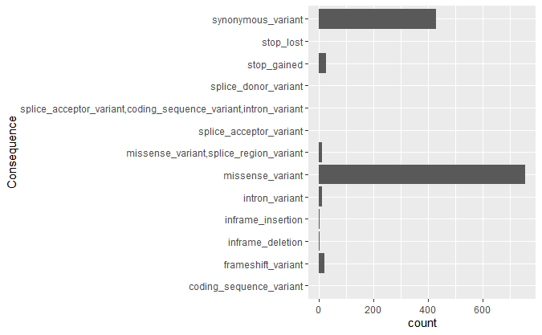

```r
w %>%
  ggplot(aes(Consequence)) +
  geom_bar() +
  coord_flip()
```

Consequence별로 각각의 IMPACT정도를 보기로 하였다.

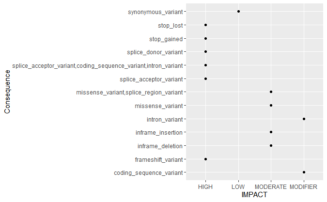

```r
w %>%
  ggplot(aes(IMPACT, Consequence)) +
  geom_point()
```

# Conslusion

# Feedback

스스로 개선해햐할점, 교수님, 학우들의 피드백을 받아서 개선해야할 점을 체크하였고 그에 따라 plot을 개선하였다.

1. 변이 평가 지표, 빈도수, 여러가지 위치 등등 - 를 충분히 사용하지 않았음.  
2. tidyverse 명령어, filtering, data wrangling에 쓰이는 명령어가 부족함

tidyverse 명령어를 통해서 dataset을 wragling을 진행하지 않아 tidyverse 명령어를 이용해서 다시 코드를 작성하였다.

```r
library(tidyverse)
w <- read_delim("table.scn2a.vep_20190916.txt", delim = '\t', skip = 91, progress = F)
w_d <- w %>% select(Gene, Feature, BIOTYPE, Consequence, IMPACT)
w_d
```

| Gene | Feature | BIOTYPE | Consequence | IMPACT |
| --- | --- | --- | --- | --- |
| ENSG00000136531 | ENST00000357398 | protein_coding | missense_variant | MODERATE |
| ENSG00000136531 | ENST00000357398 | protein_coding | synonymous_variant | LOW |
| ENSG00000136531 | ENST00000357398 | protein_coding | missense_variant | MODERATE |
| ENSG00000136531 | ENST00000357398 | protein_coding | synonymous_variant | LOW |
| ENSG00000136531 | ENST00000357398 | protein_coding | synonymous_variant | LOW |
| ENSG00000136531 | ENST00000357398 | protein_coding | missense_variant | MODERATE |
| ENSG00000136531 | ENST00000357398 | protein_coding | synonymous_variant | LOW |
| ENSG00000136531 | ENST00000357398 | protein_coding | missense_variant | MODERATE |
| ENSG00000136531 | ENST00000357398 | protein_coding | missense_variant | MODERATE |
| ENSG00000136531 | ENST00000357398 | protein_coding | missense_variant | MODERATE |

[output cut: 990 more lines]

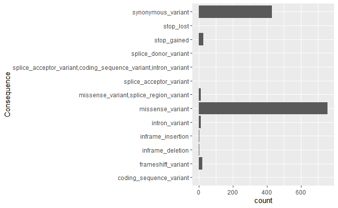

```r
w_d %>%
  ggplot(aes(Consequence)) +
  geom_bar() +
  coord_flip()
```

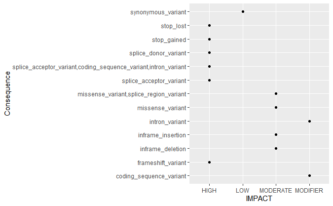

```r
w_d %>%
  ggplot(aes(IMPACT, Consequence)) +
  geom_point()
```

3. 이 plot을 이해하기 위한 제목을 달 것.  
확실히 제목이 없어 처음에 plot을 이해하는데 어려움이 있을 것임을 공감하였다. 이에 제목에 관한 코드를 하나 넣었다.

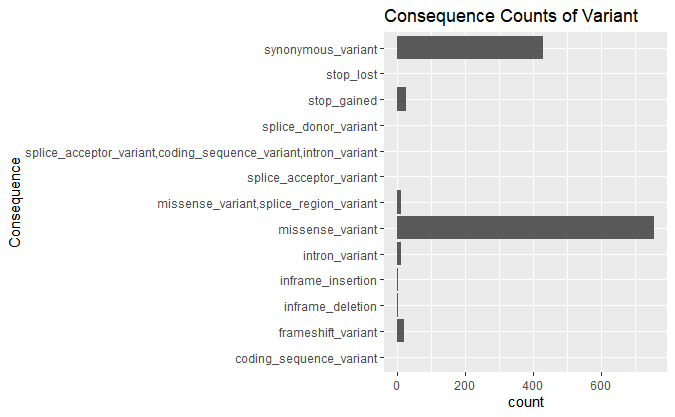

```r
#ggtitle을 이용해 제목을 추가하였다.
w_d %>%
  ggplot(aes(Consequence)) +
  geom_bar() +
  coord_flip() +
  ggtitle("Consequence Counts of Variant")
```

[figure not shown]

4. splice_acceptor_variant, coding_sequence_variant, intron_variant 항목이 너무 길어 두줄에 나누어 기록이 필요.

```r
w_d <- as.data.frame(lapply(w_d, function(w_d) if(is.character(w_d)|is.factor(w_d)) gsub("splice_acceptor_variant,coding_sequence_variant,intron_variant", "splice_acceptor_variant,\n coding_sequence_variant,\n intron_variant", w_d) else(w_d)))

w_d <- as.data.frame(lapply(w_d, function(w_d) if(is.character(w_d)|is.factor(w_d)) gsub("missense_variant,splice_region_variant", "missense_variant,\n splice_region_variant", w_d) else(w_d)))
```

이후 글씨 크기를 조절하였다.

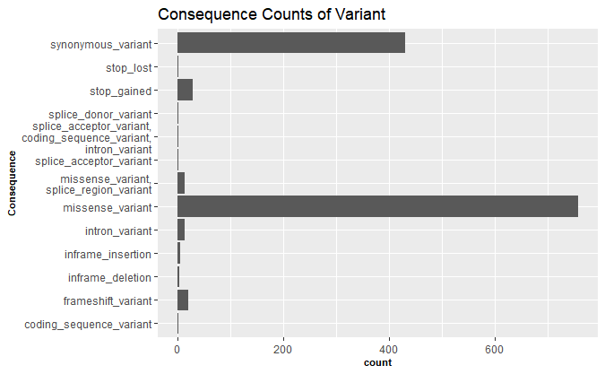

```r
w_d %>%
  ggplot(aes(Consequence)) +
  geom_bar() +
  coord_flip() +
  ggtitle("Consequence Counts of Variant") +
  theme(axis.title = element_text(face = "bold", size = 8))
```

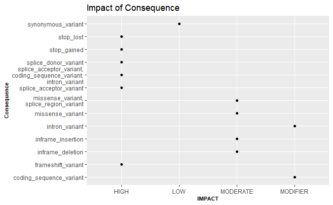

```r
w_d %>%
  ggplot(aes(IMPACT, Consequence)) +
  geom_point() +
  ggtitle("Impact of Consequence") +
  theme(axis.title = element_text(face = "bold", size = 8))
```